# Downsampled analyses

Dani Cosme

2021-07-07

This document provides the code for the analyses reported in:

Cosme et al. (Preprint) Message self and social relevance is positively related to sharing intentions: Correlational and causal evidence from six studies

In these analyses, we test correlational associations between self and social relevance and broad- and narrowcast sharing intentions in a subset of data in which the correlations between self and social relevance are lower.

# prep data

First, we load the relevant packages and data, and define the plotting aesthetics.

## load packages

```r
if (!require(tidyverse)) {
  install.packages('tidyverse')
}
if (!require(knitr)) {
  install.packages('knitr')
}
if (!require(kableExtra)) {
  install.packages('kableExtra')
}
if (!require(lmerTest)) {
  install.packages('lmerTest')
}
```

## define aesthetics

```r
palette = c("#E64626", "#FF9900", "#FFE136", "#00A896","#1985A1", "#5A69AF")
palette_sharing = c("#4c5c68", "#B8B3BE")

plot_aes = theme_minimal() +
  theme(legend.position = "top",
        legend.text = element_text(size = 12),
        text = element_text(size = 16, family = "Futura Medium"),
        axis.text = element_text(color = "black"),
        axis.line = element_line(colour = "black"),
        axis.ticks.y = element_blank())
```

## load and merge data

```r
# cleaned study data
study1 = read.csv("../data/study1.csv", stringsAsFactors = FALSE)

study2 = read.csv("../data/study2.csv", stringsAsFactors = FALSE)

study3 = read.csv("../data/study3.csv", stringsAsFactors = FALSE)

study4 = read.csv("../data/study4.csv", stringsAsFactors = FALSE)

study5 = read.csv("../data/study5.csv", stringsAsFactors = FALSE)

study6 = read.csv("../data/study6.csv", stringsAsFactors = FALSE) %>%
  select(-article_cond)

# merge dataframes and z-score within study and sharing type
merged = bind_rows(study1, study2, study3, study4, study5, study6) %>%
  group_by(study, sharing_type) %>%
  mutate(msg_share_std = scale(msg_share, scale = TRUE, center = TRUE))
```

# message-level

In these analyses, select a subset of messages that have correlations between self and social relevance < .7.

## correlations

### descriptives

Describe the correlations between self and social relevance by study and content type.

#### across content

```r
cors_spread = merged %>%
  ungroup() %>%
  select(study, item, msg_rel_self, msg_rel_social) %>%
  unique()

cors = cors_spread %>%
  nest(-c(study, item)) %>%
  mutate(test = map(data, possibly(~ cor.test(.$msg_rel_self, .$msg_rel_social), otherwise = NULL))) %>%
  filter(!test == "NULL") %>%
  mutate(coefs = map(test,
                     broom::tidy,
                     conf.int = TRUE,
                     conf.level = .95)) %>%
  unnest(coefs, .drop = TRUE) %>%
  mutate_if(is.numeric, round, 2)

cors %>%
  group_by(study) %>%
  summarize(`mean correlation` = mean(estimate, na.rm = TRUE),
            `sd correlation` = sd(estimate, na.rm = TRUE),
            min = min(estimate, na.rm = TRUE),
            max = max(estimate, na.rm = TRUE)) %>%
  mutate(`range correlation` = sprintf("%.2f, %.2f", min, max)) %>%
  select(-min, -max) %>%
  kable(digits = 2) %>%
  kableExtra::kable_styling()
```

| study | mean correlation | sd correlation | range correlation |
| --- | --- | --- | --- |
| study 1 | 0.57 | 0.23 | -0.12, 1.00 |
| study 2 | 0.64 | 0.12 | 0.48, 0.82 |
| study 3 | 0.63 | 0.14 | 0.39, 0.80 |
| study 4 | 0.56 | 0.26 | -0.18, 0.95 |
| study 5 | 0.78 | 0.15 | 0.28, 0.95 |
| study 6 | 0.75 | 0.15 | 0.23, 0.95 |

#### by content

```r
message_content = merged %>%
  ungroup() %>%
  select(study, item, content) %>%
  unique()

cors %>%
  left_join(., message_content) %>%
  group_by(study, content) %>%
  summarize(`mean correlation` = mean(estimate, na.rm = TRUE),
            `sd correlation` = sd(estimate, na.rm = TRUE),
            min = min(estimate, na.rm = TRUE),
            max = max(estimate, na.rm = TRUE)) %>%
  mutate(`range correlation` = sprintf("%.2f, %.2f", min, max)) %>%
  select(-min, -max) %>%
  kable(digits = 2) %>%
  kableExtra::kable_styling()
```

| study | content | mean correlation | sd correlation | range correlation |
| --- | --- | --- | --- | --- |
| study 1 | covid | 0.57 | 0.23 | -0.12, 1.00 |
| study 2 | voting | 0.64 | 0.12 | 0.48, 0.82 |
| study 3 | voting | 0.63 | 0.14 | 0.39, 0.80 |
| study 4 | health | 0.56 | 0.26 | -0.18, 0.95 |
| study 5 | climate | 0.84 | 0.11 | 0.43, 0.95 |
| study 5 | covid | 0.73 | 0.17 | 0.28, 0.95 |
| study 6 | climate | 0.82 | 0.09 | 0.61, 0.95 |
| study 6 | health | 0.67 | 0.16 | 0.23, 0.88 |

### plot

This plot is reported in supplementary material Figure S1.

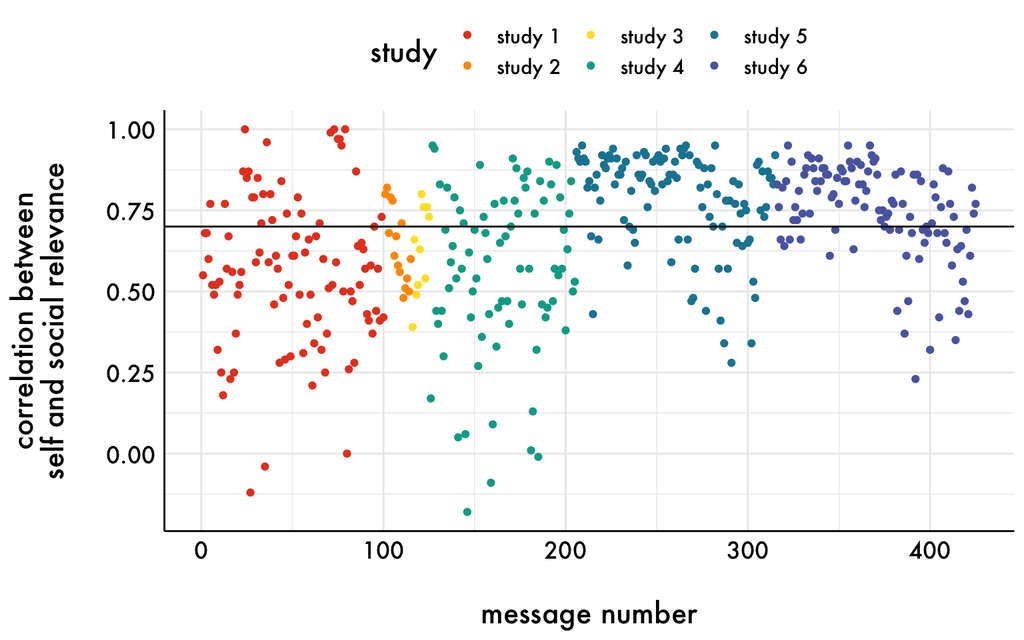

```r
cors %>%
  arrange(study, item) %>%
  mutate(item = row_number(),
         V1 = sprintf("self_%s", row_number()),
         V2 = sprintf("social_%s", row_number())) %>%
  ggplot(aes(item, estimate, color = study)) +
  geom_point() +
  geom_hline(yintercept = .7) +
  scale_color_manual(values = palette) +
  labs(x = "\nmessage number", y = "correlation between\nself and social relevance\n") +
  plot_aes +
  theme(legend.text = element_text(size = 11))
```

### number of messages per study with < .7 correlation

```r
data_lower_cors = cors %>%
  filter(estimate < .7)

total_n = merged %>%
  ungroup() %>%
  select(study, item) %>%
  unique() %>%
  group_by(study) %>%
  summarize(`total n` = n())

data_lower_cors %>%
  group_by(study) %>%
  summarize(n = n()) %>%
  left_join(., total_n) %>%
  mutate(percent = (n / `total n`) * 100) %>%
  kable(digits = 2) %>%
  kableExtra::kable_styling()
```

| study | n | total n | percent |
| --- | --- | --- | --- |
| study 1 | 72 | 101 | 71.29 |
| study 2 | 10 | 15 | 66.67 |
| study 3 | 6 | 10 | 60.00 |
| study 4 | 52 | 80 | 65.00 |
| study 5 | 25 | 110 | 22.73 |
| study 6 | 34 | 110 | 30.91 |

## downsampled mega-analysis

Estimate the mega-analysis model in the downsampled dataset.

### run model

```r
data_downsample = merged %>%
  filter(item %in% data_lower_cors$item)

model = lmerTest::lmer(msg_share_std ~ 0 + msg_rel_self_between*sharing_type +
                                 msg_rel_self_within*sharing_type +
                                 msg_rel_social_between*sharing_type +
                                 msg_rel_social_within*sharing_type +
                                 (1 + msg_rel_self_within + msg_rel_social_within | SID) +
                                 (1 + msg_rel_self_within + msg_rel_social_within | item),
                               data = data_downsample,
                       control = lmerControl(optimizer = "bobyqa"))

summary(model)
```

```
## Linear mixed model fit by REML. t-tests use Satterthwaite's method [
## lmerModLmerTest]
## Formula:
## msg_share_std ~ 0 + msg_rel_self_between * sharing_type + msg_rel_self_within *
##     sharing_type + msg_rel_social_between * sharing_type + msg_rel_social_within *
##     sharing_type + (1 + msg_rel_self_within + msg_rel_social_within |
##     SID) + (1 + msg_rel_self_within + msg_rel_social_within |      item)
##    Data: data_downsample
## Control: lmerControl(optimizer = "bobyqa")
##
## REML criterion at convergence: 35029
##
## Scaled residuals:
##     Min      1Q  Median      3Q     Max
## -4.9718 -0.4382  0.0207  0.4455  5.5000
##
## Random effects:
##  Groups   Name                  Variance Std.Dev. Corr
##  SID      (Intercept)           0.400626 0.63295
##           msg_rel_self_within   0.021716 0.14736   0.11
##           msg_rel_social_within 0.018463 0.13588   0.21 -0.11
##  item     (Intercept)           0.004909 0.07006
##           msg_rel_self_within   0.007081 0.08415  -0.29
##           msg_rel_social_within 0.001225 0.03500   0.03 -0.08
##  Residual                       0.225592 0.47496
## Number of obs: 18408, groups:  SID, 3669; item, 198
##
## Fixed effects:
##                                         Estimate   Std. Error           df
## msg_rel_self_between                    0.340561     0.020253  3669.320145
## sharing_type                            0.018216     0.011818 12681.138456
## msg_rel_self_within                     0.185392     0.010211   140.632968
## msg_rel_social_between                  0.184032     0.020184  3639.460566
## msg_rel_social_within                   0.128113     0.007838    81.547725
## msg_rel_self_between:sharing_type      -0.061099     0.021330 12692.369300
## sharing_type:msg_rel_self_within       -0.055311     0.013232  5813.281074
## sharing_type:msg_rel_social_between     0.080852     0.021529 12686.870366
## sharing_type:msg_rel_social_within      0.119225     0.013548  3237.615065
##                                     t value             Pr(>|t|)
## msg_rel_self_between                 16.815 < 0.0000000000000002 ***
```

[output cut: 24 more lines]

```
## msg_rl_scl_b
## msg_rl_scl_w
## msg_rl_s_:_            -0.023
## shrng_typ:msg_rl_sl_    0.154       -0.082
## shrng_typ:msg_rl_scl_b  0.016       -0.832  0.079
## shrng_typ:msg_rl_scl_w -0.280        0.089 -0.533
##                        shrng_typ:msg_rl_scl_b
## sharing_typ
## msg_rl_slf_w
## msg_rl_scl_b
## msg_rl_scl_w
## msg_rl_s_:_
## shrng_typ:msg_rl_sl_
## shrng_typ:msg_rl_scl_b
## shrng_typ:msg_rl_scl_w -0.063
```

### print variance inflation factors

```r
car::vif(model)
```

```
##                msg_rel_self_between                        sharing_type
##                            3.202037                            1.014622
##                 msg_rel_self_within              msg_rel_social_between
##                            1.170393                            3.203073
##               msg_rel_social_within   msg_rel_self_between:sharing_type
##                            1.197597                            3.324110
##    sharing_type:msg_rel_self_within sharing_type:msg_rel_social_between
##                            1.470215                            3.319031
##  sharing_type:msg_rel_social_within
##                            1.501391
```

### plot

This plot is reported in supplementary material Figure S2.

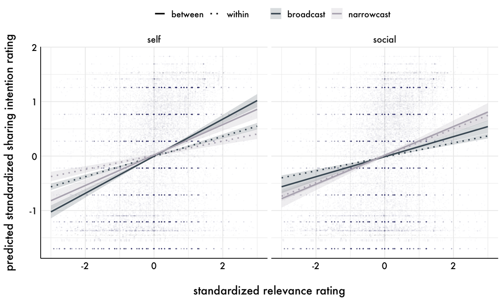

```r
predicted = ggeffects::ggpredict(model, c("msg_rel_self_between [-3:3]", "sharing_type")) %>%
  data.frame() %>%
  mutate(type = "self_between") %>%
  bind_rows(ggeffects::ggpredict(model, c("msg_rel_self_within [-3:3]", "sharing_type")) %>%
              data.frame() %>%
              mutate(type = "self_within")) %>%
  bind_rows(ggeffects::ggpredict(model, c("msg_rel_social_between [-3:3]", "sharing_type")) %>%
              data.frame() %>%
              mutate(type = "social_between")) %>%
  bind_rows(ggeffects::ggpredict(model, c("msg_rel_social_within [-3:3]", "sharing_type")) %>%
              data.frame() %>%
              mutate(type = "social_within"))

points = data_downsample %>%
  select(-group) %>%
  rename("group" = sharing_type,
         "predicted" = msg_share_std) %>%
  select(study, SID, group, predicted, contains("within"), contains("between")) %>%
  gather(type, x, contains("msg")) %>%
  mutate(type = gsub("msg_rel_", "", type),
         group = ifelse(group == 0, "broadcast", "narrowcast")) %>%
  extract(type, c("variable", "type"), "(.*)_(.*)") %>%
  filter(x < 3 & x > -3)

predicted %>%
  mutate(group = ifelse(group == 0, "broadcast", "narrowcast")) %>%
  extract(type, c("variable", "type"), "(.*)_(.*)") %>%
  ggplot(aes(x, predicted, color = group, fill = group, linetype = type)) +
  geom_point(data = points, aes(x, predicted), alpha = .02, size = .25) +
  geom_ribbon(aes(ymin = conf.low, ymax = conf.high), alpha = .2, color = NA) +
  geom_line(size = 1) +
  facet_grid(~variable) +
  scale_color_manual(name = "", values = palette_sharing) +
  scale_fill_manual(name = "", values = palette_sharing) +
  scale_linetype_manual(name = "", values = c("solid", "dotted")) +
  guides(linetype = guide_legend(override.aes = list(fill = NA))) +
  labs(x = "\nstandardized relevance rating", y = "predicted standardized sharing intention rating\n") +
  plot_aes  +
  theme(legend.position = "top")
```

### model summary table

```r
model %>%
  broom.mixed::tidy(conf.int = TRUE) %>%
  filter(effect == "fixed") %>%
  rename("SE" = std.error,
         "t" = statistic,
         "p" = p.value) %>%
  select(-group, -effect) %>%
  mutate_at(vars(-contains("term"), -contains("p.value")), round, 2) %>%
  mutate(term = gsub(":", " x ", term),
         term = gsub("msg_", "", term),
         term = gsub("_", " ", term),
         term = gsub("within", "within", term),
         term = gsub("between", "between", term),
         term = gsub("rel self", "self relevance", term),
         term = gsub("rel social", "social relevance", term),
         term = gsub("sharing type", "sharing type (narrowcast)", term),
         p = ifelse(p < .001, "< .001",
                    ifelse(p == 1, "1.000", gsub("0.(.*)", ".\\1", sprintf("%.3f", p)))),
         `b [95% CI]` = sprintf("%.2f [%0.2f, %.2f]", estimate, conf.low, conf.high)) %>%
  select(term, `b [95% CI]`, df, t, p) %>%
  kable()  %>%
  kable_styling()
```

[output not shown]

# person-level

In these analyses, select a subset of people that have correlations between self and social relevance < .7.

Because participants tended to only rate a few messages, this approach to downsampling is likely more unstable. Therefore, these analyses are supplementary and not reported in the manuscript.

## correlations

### descriptives

Describe the correlations between self and social relevance by study and content type.

#### across content

```r
cors_spread = merged %>%
  ungroup() %>%
  select(study, SID, msg_rel_self, msg_rel_social) %>%
  unique()

cors = cors_spread %>%
  nest(-c(study, SID)) %>%
  mutate(test = map(data, possibly(~ cor.test(.$msg_rel_self, .$msg_rel_social), otherwise = NULL))) %>%
  filter(!test == "NULL") %>%
  mutate(coefs = map(test,
                     broom::tidy,
                     conf.int = TRUE,
                     conf.level = .95)) %>%
  unnest(coefs, .drop = TRUE) %>%
  mutate_if(is.numeric, round, 2)

cors %>%
  group_by(study) %>%
  summarize(`mean correlation` = mean(estimate, na.rm = TRUE),
            `sd correlation` = sd(estimate, na.rm = TRUE),
            min = min(estimate, na.rm = TRUE),
            max = max(estimate, na.rm = TRUE)) %>%
  mutate(`range correlation` = sprintf("%.2f, %.2f", min, max)) %>%
  select(-min, -max) %>%
  kable(digits = 2) %>%
  kableExtra::kable_styling()
```

| study | mean correlation | sd correlation | range correlation |
| --- | --- | --- | --- |
| study 1 | 0.57 | 0.47 | -0.97, 1.00 |
| study 2 | 0.50 | 0.53 | -1.00, 1.00 |
| study 3 | 0.64 | 0.47 | -0.86, 1.00 |
| study 4 | 0.51 | 0.36 | -0.88, 0.99 |
| study 5 | 0.49 | 0.45 | -0.94, 1.00 |
| study 6 | 0.56 | 0.40 | -0.72, 1.00 |

### plot

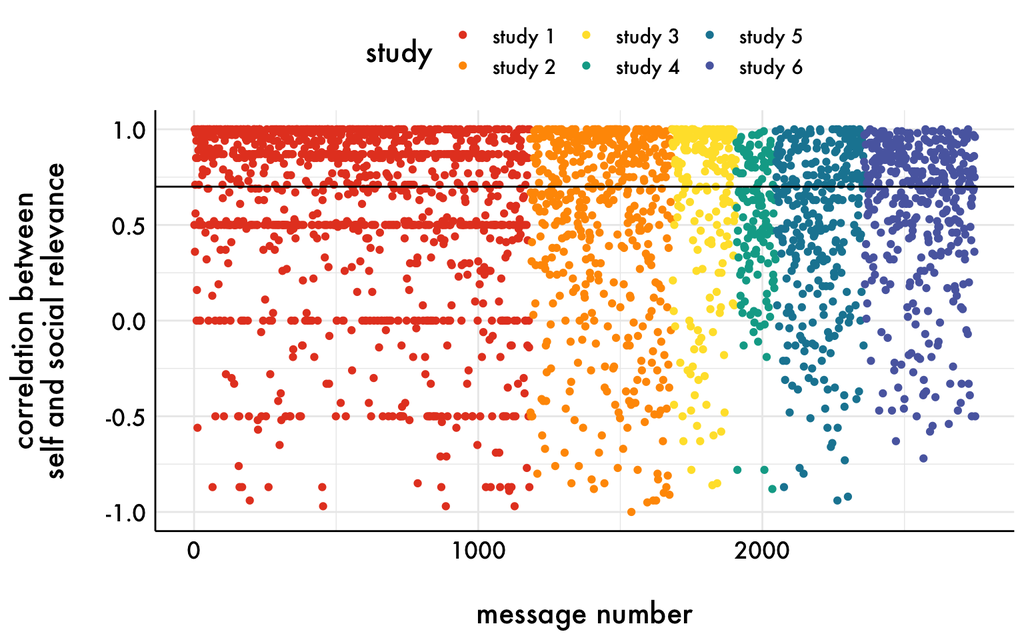

```r
cors %>%
  arrange(study, SID) %>%
  mutate(item = row_number(),
         V1 = sprintf("self_%s", row_number()),
         V2 = sprintf("social_%s", row_number())) %>%
  ggplot(aes(item, estimate, color = study)) +
  geom_point() +
  geom_hline(yintercept = .7) +
  scale_color_manual(values = palette) +
  labs(x = "\nmessage number", y = "correlation between\nself and social relevance\n") +
  plot_aes +
  theme(legend.text = element_text(size = 11))
```

### number of messages per study with < .7 correlation

```r
data_lower_cors = cors %>%
  filter(estimate < .7)

total_n = merged %>%
  ungroup() %>%
  select(study, SID) %>%
  unique() %>%
  group_by(study) %>%
  summarize(`total n` = n())

data_lower_cors %>%
  group_by(study) %>%
  summarize(n = n()) %>%
  left_join(., total_n) %>%
  mutate(percent = (n / `total n`) * 100) %>%
  kable(digits = 2) %>%
  kableExtra::kable_styling()
```

| study | n | total n | percent |
| --- | --- | --- | --- |
| study 1 | 532 | 2081 | 25.56 |
| study 2 | 257 | 547 | 46.98 |
| study 3 | 79 | 248 | 31.85 |
| study 4 | 91 | 139 | 65.47 |
| study 5 | 178 | 315 | 56.51 |
| study 6 | 198 | 397 | 49.87 |

## downsampled mega-analysis

Estimate the mega-analysis model in the downsampled dataset.

### run model

```r
data_downsample = merged %>%
  filter(SID %in% data_lower_cors$SID)

model = lmerTest::lmer(msg_share_std ~ 0 + msg_rel_self_between*sharing_type +
                                 msg_rel_self_within*sharing_type +
                                 msg_rel_social_between*sharing_type +
                                 msg_rel_social_within*sharing_type +
                                 (1 + msg_rel_self_within + msg_rel_social_within | SID) +
                                 (1 + msg_rel_self_within + msg_rel_social_within | item),
                               data = data_downsample,
                       control = lmerControl(optimizer = "bobyqa"))

car::vif(model)
```

```
##                msg_rel_self_between                        sharing_type
##                            2.154070                            1.023948
##                 msg_rel_self_within              msg_rel_social_between
##                            1.127426                            2.153909
##               msg_rel_social_within   msg_rel_self_between:sharing_type
##                            1.140417                            3.639021
##    sharing_type:msg_rel_self_within sharing_type:msg_rel_social_between
##                            1.270233                            3.672980
##  sharing_type:msg_rel_social_within
##                            1.281666
```

### plot

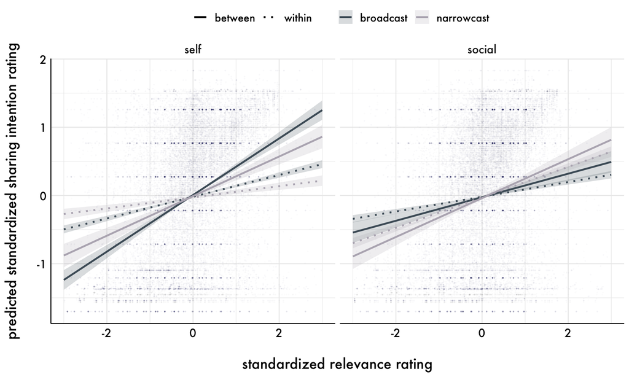

```r
predicted = ggeffects::ggpredict(model, c("msg_rel_self_between [-3:3]", "sharing_type")) %>%
  data.frame() %>%
  mutate(type = "self_between") %>%
  bind_rows(ggeffects::ggpredict(model, c("msg_rel_self_within [-3:3]", "sharing_type")) %>%
              data.frame() %>%
              mutate(type = "self_within")) %>%
  bind_rows(ggeffects::ggpredict(model, c("msg_rel_social_between [-3:3]", "sharing_type")) %>%
              data.frame() %>%
              mutate(type = "social_between")) %>%
  bind_rows(ggeffects::ggpredict(model, c("msg_rel_social_within [-3:3]", "sharing_type")) %>%
              data.frame() %>%
              mutate(type = "social_within"))

points = data_downsample %>%
  select(-group) %>%
  rename("group" = sharing_type,
         "predicted" = msg_share_std) %>%
  select(study, SID, group, predicted, contains("within"), contains("between")) %>%
  gather(type, x, contains("msg")) %>%
  mutate(type = gsub("msg_rel_", "", type),
         group = ifelse(group == 0, "broadcast", "narrowcast")) %>%
  extract(type, c("variable", "type"), "(.*)_(.*)") %>%
  filter(x < 3 & x > -3)

(fig3_alt = predicted %>%
  mutate(group = ifelse(group == 0, "broadcast", "narrowcast")) %>%
  extract(type, c("variable", "type"), "(.*)_(.*)") %>%
  ggplot(aes(x, predicted, color = group, fill = group, linetype = type)) +
  geom_point(data = points, aes(x, predicted), alpha = .02, size = .25) +
  geom_ribbon(aes(ymin = conf.low, ymax = conf.high), alpha = .2, color = NA) +
  geom_line(size = 1) +
  facet_grid(~variable) +
  scale_color_manual(name = "", values = palette_sharing) +
  scale_fill_manual(name = "", values = palette_sharing) +
  scale_linetype_manual(name = "", values = c("solid", "dotted")) +
  guides(linetype = guide_legend(override.aes = list(fill = NA))) +
  labs(x = "\nstandardized relevance rating", y = "predicted standardized sharing intention rating\n") +
  plot_aes  +
  theme(legend.position = "top"))
```

### model summary table

```r
model %>%
  broom.mixed::tidy(conf.int = TRUE) %>%
  filter(effect == "fixed") %>%
  rename("SE" = std.error,
         "t" = statistic,
         "p" = p.value) %>%
  select(-group, -effect) %>%
  mutate_at(vars(-contains("term"), -contains("p.value")), round, 2) %>%
  mutate(term = gsub(":", " x ", term),
         term = gsub("msg_", "", term),
         term = gsub("_", " ", term),
         term = gsub("within", "within", term),
         term = gsub("between", "between", term),
         term = gsub("rel self", "self relevance", term),
         term = gsub("rel social", "social relevance", term),
         term = gsub("sharing type", "sharing type (narrowcast)", term),
         p = ifelse(p < .001, "< .001",
                    ifelse(p == 1, "1.000", gsub("0.(.*)", ".\\1", sprintf("%.3f", p)))),
         `b [95% CI]` = sprintf("%.2f [%0.2f, %.2f]", estimate, conf.low, conf.high)) %>%
  select(term, `b [95% CI]`, df, t, p) %>%
  kable()  %>%
  kable_styling()
```

| term | b [95% CI] | df | t | p |
| --- | --- | --- | --- | --- |
| self relevance between | 0.41 [0.37, 0.46] | 1368.94 | 17.04 | < .001 |
| sharing type (narrowcast) | -0.02 [-0.04, -0.00] | 9734.45 | -2.05 | .040 |
| self relevance within | 0.16 [0.14, 0.18] | 332.49 | 16.12 | < .001 |
| social relevance between | 0.17 [0.12, 0.22] | 1345.79 | 6.52 | < .001 |
| social relevance within | 0.11 [0.09, 0.13] | 300.12 | 11.62 | < .001 |
| self relevance between x sharing type (narrowcast) | -0.12 [-0.16, -0.09] | 9623.17 | -6.87 | < .001 |
| sharing type (narrowcast) x self relevance within | -0.08 [-0.10, -0.06] | 8631.78 | -6.84 | < .001 |
| sharing type (narrowcast) x social relevance between | 0.11 [0.07, 0.15] | 9614.26 | 5.84 | < .001 |
| sharing type (narrowcast) x social relevance within | 0.12 [0.09, 0.14] | 7961.27 | 9.71 | < .001 |